# Module 3 - Fitting Discrete Distributions 2

2020-12-09

# Instructions

I am giving you both the raw data and the rendered Tables and Figures section. Your goal is to:

- Make a `rmd` file that knits to the `HTML` answer
- Answer the questions in the Analysis section by selecting the correct `[]` and filling out the `______`
- Hard coding the Analysis section is allowed
- Match the presented tables and/or figures in the Tables and Figures
- Do not hard code the Tables and Figures section

Please match the Analysis and Tables and Figures sections as close as you can.

Please submit both the `rmd` and your knitted `HTML` to the link on Canvas.

The data file is on Canvas as `data.csv`

**Remove the Instructions section from your final Knit.**

# Analysis

Perform a goodness-of-fit test.

# Tables and Figures

Find the maximum dice size: 12

Find the group size: 8

Considering a roll of 1/2/3 to be a success, find the number of successes per grouping.

Number of successes when rolling a 12 sided dice.

|  | 0 | 1 | 2 | 3 | 4 | 5 | 6 | 7 | 8 |
| --- | --- | --- | --- | --- | --- | --- | --- | --- | --- |
| Successes | 3013 | 7966 | 9160 | 6225 | 2643 | 711 | 101 | 12 | 0 |

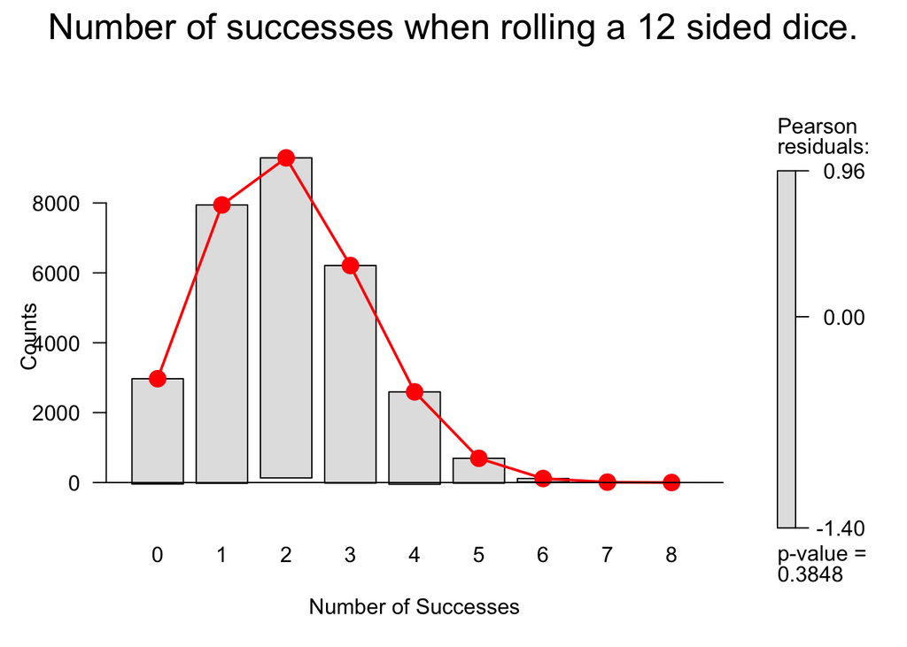